# lab1_ckp4

Fernando Lordao

9 de abril de 2018

```r
library(tidyverse)
library(here)
library(knitr)
theme_set(theme_bw())
```

## Lendo os dados

Os dados já processados dos projetos

```r
projetos = read_csv(here::here("data/projetos.csv"))
```

## Descrição Inicial

Trabalho da disciplina FPCC2 com objetivo de exercitar a manipulação de um conjunto de dados e extrair informações relevantes.

## Objetivos

Elaborar duas perguntas que possam ser lançadas a respeito dos dados e tentar elucidá-las utilizando as ferramentas vistas em sala.

## Pergunta 1

As equipes mais propensas a escrever testes são as equipes de qual linguagem?

Exemplo de resposta: as equipes que trabalhan com java são mais propensas a escrever testes de software, pois observamos uma maior quantidade de testes nos projetos que utilizam Java.

## Pergunta 2

Será que projetos pequenos no que diz respeito à quantidade de linhas de código alcançam sucesso mais facilmente que projetos grandes?

Exemplo de resposta: apesar de projetos grandes apresentarem maior complexidade decorrente do aumento na quantidade linhas, não é possível deduzir relação entre a taxa de sucesso e a quantidade de linhas do projeto.

## Exploração para resposta da pergunta 1

Inicialmante vamos plotar tests_per_klok vs lang para tentar visualizar uma relação entre elas.

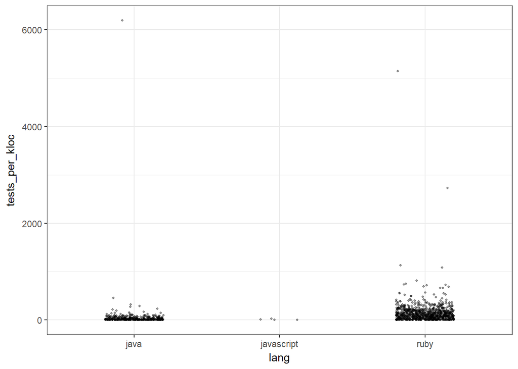

```r
projetos %>%
    ggplot(aes(x = lang,
               y = tests_per_kloc)) +
    geom_jitter(alpha = .4, width = .2, size = .8)
```

Observações iniciais:

1. Apareceu a linguagem “javascript” com pouquíssima representatividade e faremos uma exclusão dela para analisar apenas as demais (“java” e “ruby”).

```r
projetos = projetos %>%
    filter(lang != "javascript")
```

2. Há pontos isolados na parte mais alta do eixo-y e muitos pontos concentrados na parte mais baixa, tumultuando a base do gráfico e dificultando uma leitura clara da distribuição.

Vamos então modificar o eixo-y para escala logarítmica para realçar a região “tumultuada”.

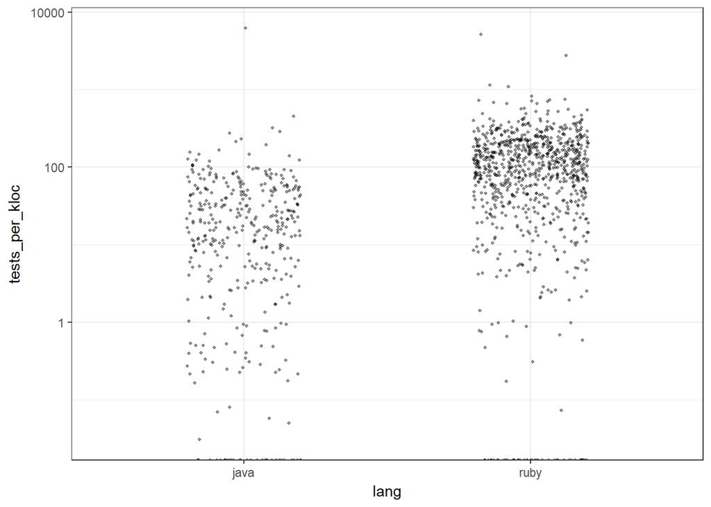

```r
projetos %>%
    ggplot(aes(x = lang,
               y = tests_per_kloc)) +
    geom_jitter(alpha = .4, width = .2, size = .8) +
    scale_y_log10()
```

Agora observamos visualmente que Ruby concentra maior quantidede de testes